# User defined functions

## User defined functions

- R has lots of predefined functions, but you can define new functions as well
- Define a function using function `function()`, and assigning the result to a *name* of our choice

```r
my_function <- function() {              # function definition
                                         #    here the R code doing something
}                                        # end of function definition
```

- You will later call the function using its name

```r
my_function()                            # function call
```

## A simple function

We can define one (or more) argument(s) within the brackets

```r
my_function <- function(x) {
  c("mean" = mean(x),  "SD" = sd(x),  "Median" = median(x),  "IQR" = IQR(x))
}

vector1 <- 1:10;  vector2 <- 11:20
my_function(vector1)
```

```
   mean      SD  Median     IQR
5.50000 3.02765 5.50000 4.50000
```

```r
my_function(vector2)
```

```
    mean       SD   Median      IQR
15.50000  3.02765 15.50000  4.50000
```

## Improving the output: rounding

```r
my_function <- function(x) {
  res <- c("mean" = mean(x),  "SD" = sd(x),  "Median" = median(x),  "IQR" = IQR(x))
  round(res, 2)
}

my_function(vector1)
```

```
  mean     SD Median    IQR
  5.50   3.03   5.50   4.50
```

More flexibility:

Could we allow for a different number of decimals?

## Arguments with default value

```r
my_function <- function(x, decimals=2) {
  res <- c("mean" = mean(x),  "SD" = sd(x),  "Median" = median(x),  "IQR" = IQR(x))
  round(res, decimals)
}

my_function(vector1)
```

```
  mean     SD Median    IQR
  5.50   3.03   5.50   4.50
```

```r
my_function(vector1, 4)
```

```
  mean     SD Median    IQR
5.5000 3.0277 5.5000 4.5000
```

## What the function returns

A function always returns the result of its *last line* of code

Why this does not produce the desired result?

```r
my_function <- function(x, decimals=2) {
  mean(x)
  sd(x)           # last line of the function body will be returned
}

my_function(1:5)
```

```
[1] 1.581139
```

The mean was actually computed, but not returned !

## Births, again

```r
library(mosaic)
data(Births78)
library(dplyr)
d <- Births78 %>%
  mutate(day = recode(day_of_week,
                      `1` = "Sun",
                      `7` = "Sat",
                      .default = "Working"),
         day= factor(day, levels = c("Working", "Sat", "Sun"))) %>%
  select( -day_of_week) #, -day_of_year)
```

## A first model and its graphical representation

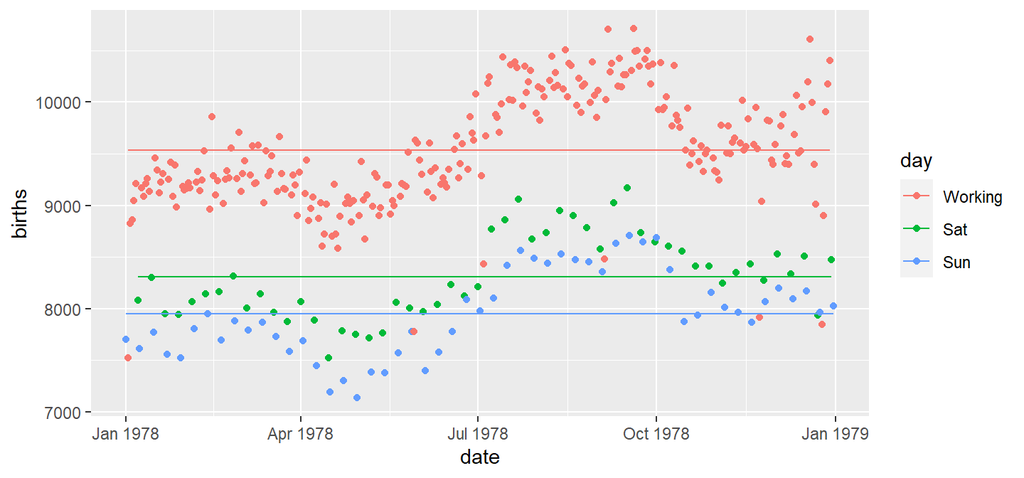

```r
model <- lm(births ~ day, data = d)                  # fit the model
d$pred <- predict(model)                            # save predictions
gf_point(births ~ date, col = ~ day, data = d) %>%    # plot the data
  gf_line(pred ~ date)                              # with predictions
```

## What will you do for a different model?

1. Copy paste
2. Change what is needed: just the model formula

```r
model <- lm(births ~ day, data = d)
d$pred <- predict(model)
gf_point(births ~ date, col = ~ day, data = d) %>%
  gf_line(pred ~ date)

model <- lm(births ~ day + month, data = d)         # change model formula
d$pred <- predict(model)
gf_point(births ~ date, col = ~ day, data = d) %>%
  gf_line(pred ~ date)
```

It’s ok, but if you need to fit other models, there is a better solution:

write a function

## Writing functions

Methodology:

1. Solve a particular case (as we did)
2. Identify the part to change, if copy paste (as we did)
3. Give a name to the part to change, replace, and test
4. Wrap the code inside a function, and use this name as argument

## Step 3. Name the part to change, and replace

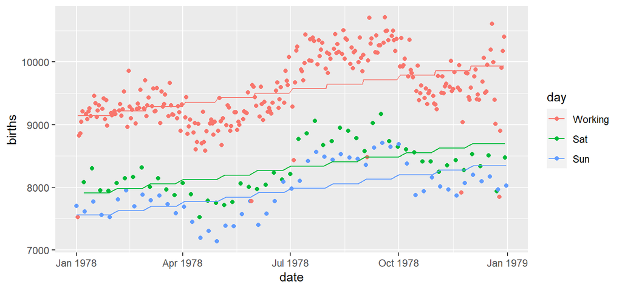

```r
the_formula <- births ~ day + month         # give a name for the formula

model <- lm(the_formula, data = d)          # replace
d$pred <- predict(model)
gf_point(births ~ date, col = ~ day, data = d) %>%
  gf_line(pred ~ date)
```

## Step 4. Wrap inside a function, with argument

```r
my_function <- function(the_formula) {      # start function definition (argument_name)

  model <- lm(the_formula, data = d)
  d$pred <- predict(model)
  gf_point(births ~ date, col = ~ day, data = d) %>%
    gf_line(pred ~ date)

}                                        # function end
```

## Call the function…

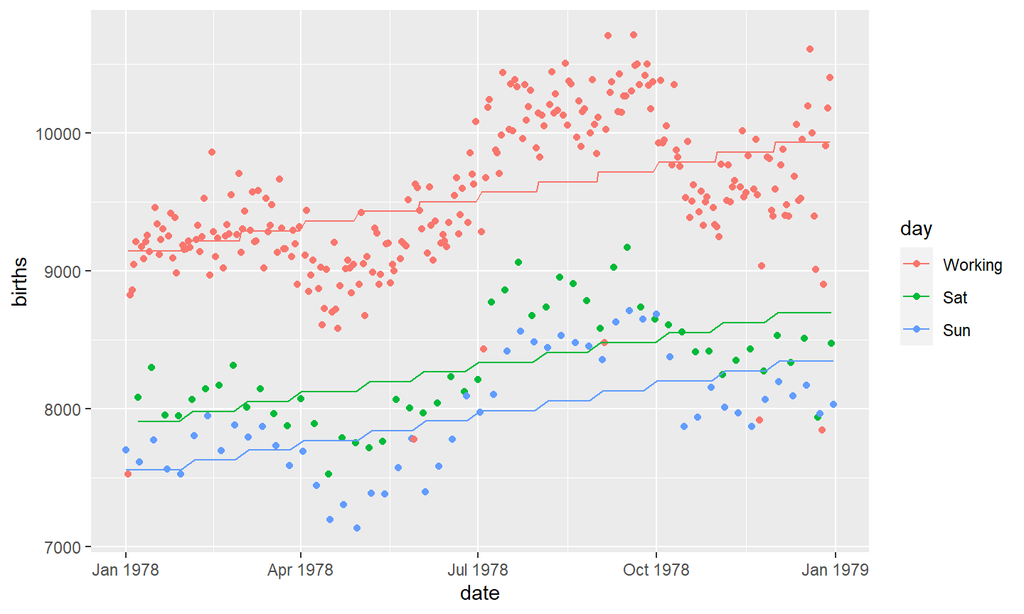

```r
my_function(births ~ day + month)
```

## …as many times as you need

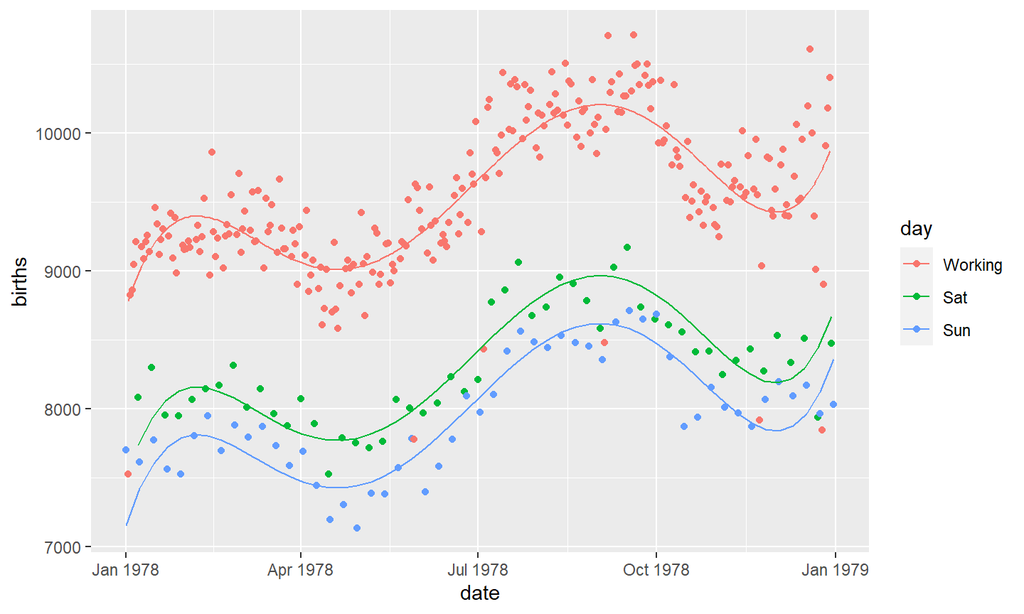

```r
my_function(births ~ day + poly(day_of_year,5))
```

## Exercise

Write a function to produce boxplots with mean as a red dot.

Use the function to produce boxplots for

- births by week day
- births by month (you will need to first convert month to a factor)
- age by smoking status in the `CompareGroups::predimed` dataset
- BMI by sex in the `CompareGroups::predimed` dataset

```r
library(compareGroups)
data(predimed)
```